# Udacity EDA Visualization Project

## Preliminary Wrangling

```python
# import all packages and set plots to be embedded inline
import numpy as np
import pandas as pd
import matplotlib.pyplot as plt
import seaborn as sns
import warnings
warnings.filterwarnings("ignore", category=DeprecationWarning)
%matplotlib inline
```

```python
#Reading in the Data
data = pd.read_csv('prosperLoanData.csv')
data
```

|  | ListingKey | ListingNumber | ListingCreationDate | CreditGrade | Term | LoanStatus | ClosedDate | BorrowerAPR | BorrowerRate | LenderYield | ... | LP_ServiceFees | LP_CollectionFees | LP_GrossPrincipalLoss | LP_NetPrincipalLoss | LP_NonPrincipalRecoverypayments | PercentFunded | Recommendations | InvestmentFromFriendsCount | InvestmentFromFriendsAmount | Investors |
| --- | --- | --- | --- | --- | --- | --- | --- | --- | --- | --- | --- | --- | --- | --- | --- | --- | --- | --- | --- | --- | --- |
| 0 | 1021339766868145413AB3B | 193129 | 2007-08-26 19:09:29.263000000 | C | 36 | Completed | 2009-08-14 00:00:00 | 0.16516 | 0.1580 | 0.1380 | ... | -133.18 | 0.0 | 0.0 | 0.0 | 0.0 | 1.0 | 0 | 0 | 0.0 | 258 |
| 1 | 10273602499503308B223C1 | 1209647 | 2014-02-27 08:28:07.900000000 | NaN | 36 | Current | NaN | 0.12016 | 0.0920 | 0.0820 | ... | 0.00 | 0.0 | 0.0 | 0.0 | 0.0 | 1.0 | 0 | 0 | 0.0 | 1 |
| 2 | 0EE9337825851032864889A | 81716 | 2007-01-05 15:00:47.090000000 | HR | 36 | Completed | 2009-12-17 00:00:00 | 0.28269 | 0.2750 | 0.2400 | ... | -24.20 | 0.0 | 0.0 | 0.0 | 0.0 | 1.0 | 0 | 0 | 0.0 | 41 |
| 3 | 0EF5356002482715299901A | 658116 | 2012-10-22 11:02:35.010000000 | NaN | 36 | Current | NaN | 0.12528 | 0.0974 | 0.0874 | ... | -108.01 | 0.0 | 0.0 | 0.0 | 0.0 | 1.0 | 0 | 0 | 0.0 | 158 |
| 4 | 0F023589499656230C5E3E2 | 909464 | 2013-09-14 18:38:39.097000000 | NaN | 36 | Current | NaN | 0.24614 | 0.2085 | 0.1985 | ... | -60.27 | 0.0 | 0.0 | 0.0 | 0.0 | 1.0 | 0 | 0 | 0.0 | 20 |
| ... | ... | ... | ... | ... | ... | ... | ... | ... | ... | ... | ... | ... | ... | ... | ... | ... | ... | ... | ... | ... | ... |
| 113932 | E6D9357655724827169606C | 753087 | 2013-04-14 05:55:02.663000000 | NaN | 36 | Current | NaN | 0.22354 | 0.1864 | 0.1764 | ... | -75.58 | 0.0 | 0.0 | 0.0 | 0.0 | 1.0 | 0 | 0 | 0.0 | 1 |
| 113933 | E6DB353036033497292EE43 | 537216 | 2011-11-03 20:42:55.333000000 | NaN | 36 | FinalPaymentInProgress | NaN | 0.13220 | 0.1110 | 0.1010 | ... | -30.05 | 0.0 | 0.0 | 0.0 | 0.0 | 1.0 | 0 | 0 | 0.0 | 22 |
| 113934 | E6E13596170052029692BB1 | 1069178 | 2013-12-13 05:49:12.703000000 | NaN | 60 | Current | NaN | 0.23984 | 0.2150 | 0.2050 | ... | -16.91 | 0.0 | 0.0 | 0.0 | 0.0 | 1.0 | 0 | 0 | 0.0 | 119 |
| 113935 | E6EB3531504622671970D9E | 539056 | 2011-11-14 13:18:26.597000000 | NaN | 60 | Completed | 2013-08-13 00:00:00 | 0.28408 | 0.2605 | 0.2505 | ... | -235.05 | 0.0 | 0.0 | 0.0 | 0.0 | 1.0 | 0 | 0 | 0.0 | 274 |
| 113936 | E6ED3600409833199F711B7 | 1140093 | 2014-01-15 09:27:37.657000000 | NaN | 36 | Current | NaN | 0.13189 | 0.1039 | 0.0939 | ... | -1.70 | 0.0 | 0.0 | 0.0 | 0.0 | 1.0 | 0 | 0 | 0.0 | 1 |

113937 rows × 81 columns

```python
#Checking the shape of the data

data.shape
```

```
(113937, 81)
```

```python
#checking the features of the data

data.info()
```

```
<class 'pandas.core.frame.DataFrame'>
RangeIndex: 113937 entries, 0 to 113936
Data columns (total 81 columns):
 #   Column                               Non-Null Count   Dtype
---  ------                               --------------   -----
 0   ListingKey                           113937 non-null  object
 1   ListingNumber                        113937 non-null  int64
 2   ListingCreationDate                  113937 non-null  object
 3   CreditGrade                          28953 non-null   object
 4   Term                                 113937 non-null  int64
 5   LoanStatus                           113937 non-null  object
 6   ClosedDate                           55089 non-null   object
 7   BorrowerAPR                          113912 non-null  float64
 8   BorrowerRate                         113937 non-null  float64
 9   LenderYield                          113937 non-null  float64
```

[output cut: 73 more lines]

##### Selecting the features that i believe would be important to the analysis

```python
column_list = ['ListingKey','CreditGrade','Term','LoanStatus','BorrowerAPR','BorrowerRate','ProsperRating (Alpha)','ProsperScore','ListingCategory (numeric)','BorrowerState','Occupation','EmploymentStatus','EmploymentStatusDuration','IsBorrowerHomeowner','DebtToIncomeRatio','StatedMonthlyIncome','TotalProsperLoans','ProsperPrincipalBorrowed','ProsperPrincipalOutstanding','DelinquenciesLast7Years','Recommendations']
```

```python
data = data[data.columns[data.columns.isin(column_list)]]
```

```python
data.info()
```

```
<class 'pandas.core.frame.DataFrame'>
RangeIndex: 113937 entries, 0 to 113936
Data columns (total 21 columns):
 #   Column                       Non-Null Count   Dtype
---  ------                       --------------   -----
 0   ListingKey                   113937 non-null  object
 1   CreditGrade                  28953 non-null   object
 2   Term                         113937 non-null  int64
 3   LoanStatus                   113937 non-null  object
 4   BorrowerAPR                  113912 non-null  float64
 5   BorrowerRate                 113937 non-null  float64
 6   ProsperRating (Alpha)        84853 non-null   object
 7   ProsperScore                 84853 non-null   float64
 8   ListingCategory (numeric)    113937 non-null  int64
 9   BorrowerState                108422 non-null  object
 10  Occupation                   110349 non-null  object
 11  EmploymentStatus             111682 non-null  object
 12  EmploymentStatusDuration     106312 non-null  float64
 13  IsBorrowerHomeowner          113937 non-null  bool
 14  DelinquenciesLast7Years      112947 non-null  float64
 15  DebtToIncomeRatio            105383 non-null  float64
 16  StatedMonthlyIncome          113937 non-null  float64
 17  TotalProsperLoans            22085 non-null   float64
 18  ProsperPrincipalBorrowed     22085 non-null   float64
 19  ProsperPrincipalOutstanding  22085 non-null   float64
 20  Recommendations              113937 non-null  int64
dtypes: bool(1), float64(10), int64(3), object(7)
memory usage: 17.5+ MB
```

#### Cleaning the Data

```python
#Removing the duplicates in the listing key, from the data dictionary it is meant to have unique values

data.drop_duplicates(subset='ListingKey', inplace = True)
```

```python
data['ListingKey'].nunique()
```

```
113066
```

```python
#make copies of the data

data_copy = data.copy()
data_copy_1 = data.copy()
```

```python
data_copy.dropna(subset='ProsperScore', inplace = True)
```

```python
data_copy.info()
```

```
<class 'pandas.core.frame.DataFrame'>
Int64Index: 83982 entries, 1 to 113936
Data columns (total 21 columns):
 #   Column                       Non-Null Count  Dtype
---  ------                       --------------  -----
 0   ListingKey                   83982 non-null  object
 1   CreditGrade                  0 non-null      object
 2   Term                         83982 non-null  int64
 3   LoanStatus                   83982 non-null  object
 4   BorrowerAPR                  83982 non-null  float64
 5   BorrowerRate                 83982 non-null  float64
 6   ProsperRating (Alpha)        83982 non-null  object
 7   ProsperScore                 83982 non-null  float64
 8   ListingCategory (numeric)    83982 non-null  int64
 9   BorrowerState                83982 non-null  object
 10  Occupation                   82708 non-null  object
 11  EmploymentStatus             83982 non-null  object
 12  EmploymentStatusDuration     83963 non-null  float64
 13  IsBorrowerHomeowner          83982 non-null  bool
 14  DelinquenciesLast7Years      83982 non-null  float64
 15  DebtToIncomeRatio            76768 non-null  float64
 16  StatedMonthlyIncome          83982 non-null  float64
 17  TotalProsperLoans            19635 non-null  float64
 18  ProsperPrincipalBorrowed     19635 non-null  float64
 19  ProsperPrincipalOutstanding  19635 non-null  float64
 20  Recommendations              83982 non-null  int64
dtypes: bool(1), float64(10), int64(3), object(7)
memory usage: 13.5+ MB
```

```python
#drop the credit grade column

data_copy.drop(columns =['CreditGrade'], inplace = True)
```

```python
#Ensuring that the data is clean without any non values
#using the Total Prosper loans, we would want to analyze customers based on their previous prosper loans, so

data_copy.dropna(subset ='TotalProsperLoans', inplace = True)
```

```python
data_copy.dropna(subset='Occupation', inplace = True)
```

```python
data_copy.dropna(subset = 'DebtToIncomeRatio', inplace = True)
```

```python
data_copy.dropna(subset = 'EmploymentStatusDuration', inplace = True)
```

```python
#test
data_copy.info()
```

```
<class 'pandas.core.frame.DataFrame'>
Int64Index: 17553 entries, 4 to 113935
Data columns (total 20 columns):
 #   Column                       Non-Null Count  Dtype
---  ------                       --------------  -----
 0   ListingKey                   17553 non-null  object
 1   Term                         17553 non-null  int64
 2   LoanStatus                   17553 non-null  object
 3   BorrowerAPR                  17553 non-null  float64
 4   BorrowerRate                 17553 non-null  float64
 5   ProsperRating (Alpha)        17553 non-null  object
 6   ProsperScore                 17553 non-null  float64
 7   ListingCategory (numeric)    17553 non-null  int64
 8   BorrowerState                17553 non-null  object
 9   Occupation                   17553 non-null  object
 10  EmploymentStatus             17553 non-null  object
 11  EmploymentStatusDuration     17553 non-null  float64
 12  IsBorrowerHomeowner          17553 non-null  bool
 13  DelinquenciesLast7Years      17553 non-null  float64
 14  DebtToIncomeRatio            17553 non-null  float64
 15  StatedMonthlyIncome          17553 non-null  float64
 16  TotalProsperLoans            17553 non-null  float64
 17  ProsperPrincipalBorrowed     17553 non-null  float64
 18  ProsperPrincipalOutstanding  17553 non-null  float64
 19  Recommendations              17553 non-null  int64
dtypes: bool(1), float64(10), int64(3), object(6)
memory usage: 2.7+ MB
```

```python
data_copy.sample(10)
```

|  | ListingKey | Term | LoanStatus | BorrowerAPR | BorrowerRate | ProsperRating (Alpha) | ProsperScore | ListingCategory (numeric) | BorrowerState | Occupation | EmploymentStatus | EmploymentStatusDuration | IsBorrowerHomeowner | DelinquenciesLast7Years | DebtToIncomeRatio | StatedMonthlyIncome | TotalProsperLoans | ProsperPrincipalBorrowed | ProsperPrincipalOutstanding | Recommendations |
| --- | --- | --- | --- | --- | --- | --- | --- | --- | --- | --- | --- | --- | --- | --- | --- | --- | --- | --- | --- | --- |
| 6511 | 095135261378281011499F0 | 36 | Completed | 0.25486 | 0.2205 | C | 5.0 | 1 | TX | Accountant/CPA | Employed | 14.0 | True | 0.0 | 0.33 | 6250.000000 | 1.0 | 2000.0 | 0.01 | 0 |
| 20478 | 48813543906254014922329 | 36 | Chargedoff | 0.26681 | 0.2287 | D | 4.0 | 1 | CA | Civil Service | Employed | 78.0 | False | 2.0 | 0.13 | 10500.000000 | 3.0 | 12250.0 | 1449.54 | 0 |
| 101556 | D3D63573559828863189911 | 60 | Current | 0.12716 | 0.1049 | A | 10.0 | 1 | IL | Retail Management | Employed | 176.0 | False | 0.0 | 0.22 | 4250.000000 | 3.0 | 7700.0 | 1319.12 | 0 |
| 67613 | FA8A35840145577305D253F | 60 | Current | 0.24589 | 0.2209 | C | 3.0 | 1 | FL | Other | Employed | 135.0 | True | 7.0 | 0.46 | 4333.333333 | 1.0 | 17500.0 | 16205.94 | 0 |
| 94132 | D55734773020637532D29BC | 36 | Completed | 0.11296 | 0.0920 | A | 9.0 | 6 | NY | Skilled Labor | Full-time | 162.0 | True | 0.0 | 0.19 | 4250.000000 | 1.0 | 6500.0 | 2900.51 | 0 |
| 77296 | FDCD3543179046562C32CD9 | 36 | Completed | 0.26681 | 0.2287 | D | 5.0 | 18 | VA | Computer Programmer | Employed | 1.0 | True | 0.0 | 0.27 | 13333.333333 | 2.0 | 11500.0 | 2713.54 | 0 |
| 15564 | B20435823759549007D77BE | 36 | Current | 0.20462 | 0.1679 | B | 6.0 | 2 | CA | Psychologist | Employed | 34.0 | False | 22.0 | 0.06 | 8583.333333 | 2.0 | 8700.0 | 735.98 | 0 |
| 20963 | BD783595389044666268723 | 60 | Current | 0.16969 | 0.1465 | B | 9.0 | 2 | IN | Skilled Labor | Employed | 105.0 | False | 0.0 | 0.25 | 5833.333333 | 2.0 | 27000.0 | 9507.05 | 0 |
| 48820 | A3663514133627125C41FD9 | 36 | Completed | 0.32576 | 0.2899 | E | 2.0 | 3 | OH | Laborer | Full-time | 211.0 | True | 0.0 | 0.28 | 5000.000000 | 3.0 | 7100.0 | 1530.42 | 0 |
| 81311 | 56A43469744441403F2C206 | 36 | Completed | 0.10846 | 0.1050 | AA | 8.0 | 7 | TX | Social Worker | Full-time | 39.0 | True | 0.0 | 0.12 | 4763.166667 | 1.0 | 8900.0 | 3716.95 | 0 |

```python
order_1 = data_copy.LoanStatus.value_counts(normalize = True).index
x = data_copy.LoanStatus.value_counts(normalize = True)
```

##### After cleaning the prosper loan data, we have left with 17553 rows to work with

#### What is the summary of the borrowers by Loan Status and Employment Status?

```
** CHART U1 **
```

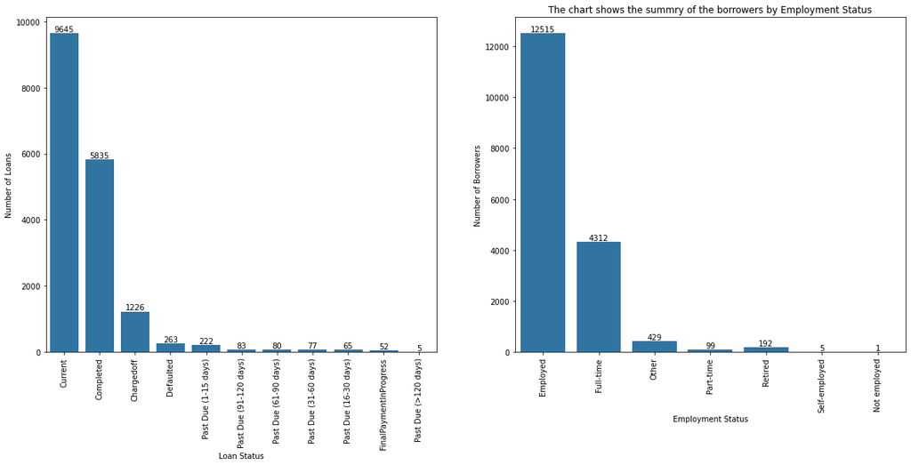

```python
print('** CHART U1 **')
plt.figure(figsize = [20,8])
plt.subplot(1,2,1);
base_color = sns.color_palette()[0]
ax = sns.countplot(data = data_copy, x = 'LoanStatus' ,color = base_color, order = order_1);
ax.bar_label(ax.containers[0]);
plt.xticks(rotation = 90);
plt.title('The Chart shows the summary of borrowers by Loan Status')
plt.ylabel('Number of Loans');
plt.xlabel('Loan Status');

#--------------------------------------------------------------------------------------------------------------------------#

plt.subplot(1,2,2);
plt.title('The chart shows the summry of the borrowers by Employment Status')
base_color = sns.color_palette()[0]
ax = sns.countplot(data = data_copy, x = 'EmploymentStatus' ,color = base_color);
ax.bar_label(ax.containers[0]);
plt.xticks(rotation = 90);
plt.ylabel('Number of Borrowers');
plt.xlabel('Employment Status');
```

```python
order_2 = data_copy.BorrowerState.value_counts(normalize = True).index
```

#### What is the distribution of the borrowers by State.

```
** CHART U2 **
```

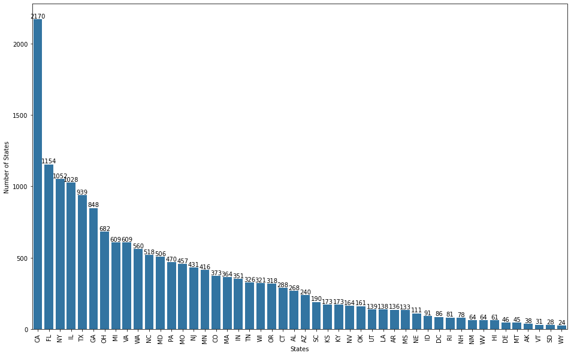

```python
print('** CHART U2 **')
plt.figure(figsize = [16,10])
base_color = sns.color_palette()[0]
ax = sns.countplot(data = data_copy, x = 'BorrowerState' ,color = base_color, order = order_2);
ax.bar_label(ax.containers[0]);
plt.xticks(rotation = 90);
plt.title('Distribution of borrowers by State')
plt.ylabel('Number of States');
plt.xlabel('States');
```

#### What is the average monthly income of the borrowers?

```
** CHART U3 **
```

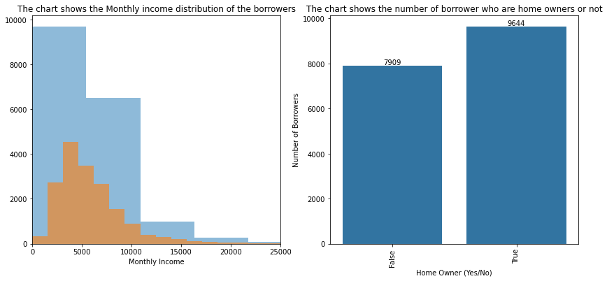

```python
print('** CHART U3 **')
plt.figure(figsize = (14,6))
plt.subplot(1,2,1)
plt.title('The chart shows the Monthly income distribution of the borrowers')
plt.hist(data = data_copy, x = 'StatedMonthlyIncome', bins = 20, alpha = 0.5);

plt.hist(data = data_copy, x = 'StatedMonthlyIncome', bins = 70, alpha = 0.6);
plt.xlim(0,25000);
plt.xlabel('Monthly Income');

#--------------------------------------------------------------------------------------------------------------------------#

plt.subplot(1,2,2)
base_color = sns.color_palette()[0]
ax = sns.countplot(data = data_copy, x = 'IsBorrowerHomeowner' ,color = base_color);
ax.bar_label(ax.containers[0]);
plt.xticks(rotation = 90);
plt.title('The chart shows the number of borrower who are home owners or not')
plt.ylabel('Number of Borrowers');
plt.xlabel('Home Owner (Yes/No)');
```

```
** CHART U4 **
```

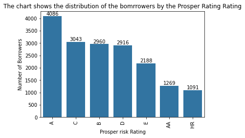

```python
print('** CHART U4 **')
order_a = data_copy['ProsperRating (Alpha)'].value_counts(normalize = True).index
ax = sns.countplot(data = data_copy, x = 'ProsperRating (Alpha)' ,color = base_color, order = order_a);
ax.bar_label(ax.containers[0]);
plt.xticks(rotation = 90);
plt.title('The chart shows the distribution of the bomrrowers by the Prosper Rating Rating')
plt.ylabel('Number of Borrowers');
plt.xlabel('Prosper risk Rating');
```

- Chart U1 basically visualizes the status of the prosper loans by categories, we see that 9645 (about 56%) of the loans are currently running and 5835 have completed the cycle from borrowinf to repayemnt.
- 12,515 of the Borrowers with prosper loans are employed - but not a full time employment, only 4312 are fully employed, with 192 of the borrower being retirees and just 1 unemployed borrower.
- Chart U2 shows the distribution of loans by States, with califonia(CA) have the highest number of prosper loans standing at 2170, followed by Florida,New York,Illinois and Texas for Top 5.
- Chart U3 visualizes the distribution of the Monthly income of the borrowers as stated by them, the median of the data is around USD 5,000 , which means that most of the borrowers earn around USD5k on an average.
- The distribution of the borrower's rating show that the A rated borrowers are more that all the other ratings.

### Bivariate Exploration

```python
data_copy.LoanStatus.value_counts()
```

```
Current                   9645
Completed                 5835
Chargedoff                1226
Defaulted                  263
Past Due (1-15 days)       222
Past Due (91-120 days)      83
Past Due (61-90 days)       80
Past Due (31-60 days)       77
Past Due (16-30 days)       65
FinalPaymentInProgress      52
Past Due (>120 days)         5
Name: LoanStatus, dtype: int64
```

#### For the bivariate, there is some transaformations to be done, We are creating another column that would have just Completed and defaulted from the Loan status column.

```python
def transform(df):

    if df['LoanStatus'] == 'Completed':
         return 'Completed'
    elif df['LoanStatus'] == 'Chargedoff': #loan is considered “charged-off” after a borrower misses 5 consecutive monthly payments
        #We would consider this also Defaulted
        return 'Defaulted'
    elif df['LoanStatus'] == 'Defaulted':
        return 'Defaulted'
    elif df['LoanStatus'] == 'Past Due (1-15 days)':
        return 'Defaulted'
    elif df['LoanStatus'] == 'Past Due (91-120 days)':
        return 'Defaulted'
    elif df['LoanStatus'] == 'Past Due (61-90 days)':
        return 'Defaulted'
    elif df['LoanStatus'] == 'Past Due (31-60 days)':
        return 'Defaulted'
    elif df['LoanStatus'] == 'Past Due (16-30 days)':
        return 'Defaulted'
    elif df['LoanStatus'] == 'Past Due (>120 days)':
        return 'Defaulted'
    else:
        return 'Not Applicable'
```

```python
data_copy['TransformedCategory'] = data_copy.apply(lambda x: transform(x),axis = 1)
```

```python
data_copy
```

|  | ListingKey | Term | LoanStatus | BorrowerAPR | BorrowerRate | ProsperRating (Alpha) | ProsperScore | ListingCategory (numeric) | BorrowerState | Occupation | ... | EmploymentStatusDuration | IsBorrowerHomeowner | DelinquenciesLast7Years | DebtToIncomeRatio | StatedMonthlyIncome | TotalProsperLoans | ProsperPrincipalBorrowed | ProsperPrincipalOutstanding | Recommendations | TransformedCategory |
| --- | --- | --- | --- | --- | --- | --- | --- | --- | --- | --- | --- | --- | --- | --- | --- | --- | --- | --- | --- | --- | --- |
| 4 | 0F023589499656230C5E3E2 | 36 | Current | 0.24614 | 0.2085 | D | 4.0 | 2 | MN | Executive | ... | 44.0 | True | 0.0 | 0.26 | 9583.333333 | 1.0 | 11000.0 | 9947.90 | 0 | Not Applicable |
| 16 | 0F4835843081468212F0892 | 60 | Current | 0.30748 | 0.2809 | E | 4.0 | 6 | CA | Professional | ... | 133.0 | True | 12.0 | 0.15 | 8291.666667 | 3.0 | 10700.0 | 4064.87 | 0 | Not Applicable |
| 19 | 0FFC35866018516621B0D3F | 60 | Current | 0.24754 | 0.2225 | D | 8.0 | 1 | OR | Laborer | ... | 18.0 | False | 0.0 | 0.41 | 3075.000000 | 1.0 | 8000.0 | 5786.00 | 0 | Not Applicable |
| 33 | 0F6B3496936961316AEE1B2 | 36 | Completed | 0.08191 | 0.0785 | AA | 10.0 | 7 | IL | Other | ... | 7.0 | False | 0.0 | 0.05 | 13083.333333 | 1.0 | 4000.0 | 0.01 | 0 | Completed |
| 47 | 0F8B3577039176552F6CC26 | 36 | Current | 0.15833 | 0.1299 | A | 8.0 | 1 | CO | Professional | ... | 90.0 | True | 0.0 | 0.35 | 5416.666667 | 3.0 | 27000.0 | 11308.14 | 1 | Not Applicable |
| ... | ... | ... | ... | ... | ... | ... | ... | ... | ... | ... | ... | ... | ... | ... | ... | ... | ... | ... | ... | ... | ... |
| 113924 | E340356181565702714DBCE | 60 | Current | 0.17317 | 0.1499 | A | 8.0 | 13 | WA | Other | ... | 56.0 | False | 2.0 | 0.17 | 3208.333333 | 2.0 | 9300.0 | 5094.62 | 1 | Not Applicable |
| 113928 | E34935176664905343E01EA | 36 | Completed | 0.22362 | 0.1899 | C | 6.0 | 3 | CO | Other | ... | 22.0 | False | 0.0 | 0.27 | 2333.333333 | 5.0 | 14250.0 | 0.02 | 0 | Completed |
| 113930 | E35D3584034795373BCD69A | 36 | Current | 0.20053 | 0.1639 | B | 6.0 | 1 | IN | Professional | ... | 85.0 | True | 0.0 | 0.20 | 6250.000000 | 1.0 | 2000.0 | 889.75 | 0 | Not Applicable |
| 113933 | E6DB353036033497292EE43 | 36 | FinalPaymentInProgress | 0.13220 | 0.1110 | A | 8.0 | 7 | PA | Professional | ... | 21.0 | True | 4.0 | 0.11 | 8041.666667 | 3.0 | 33501.0 | 4815.42 | 0 | Not Applicable |
| 113935 | E6EB3531504622671970D9E | 60 | Completed | 0.28408 | 0.2605 | C | 5.0 | 2 | GA | Food Service | ... | 94.0 | True | 0.0 | 0.48 | 3875.000000 | 1.0 | 5000.0 | 3264.37 | 0 | Completed |

17553 rows × 21 columns

```python
data_copy['TransformedCategory'].value_counts()
```

```
Not Applicable    9697
Completed         5835
Defaulted         2021
Name: TransformedCategory, dtype: int64
```

```python
temp = data_copy[(data_copy['TransformedCategory'] != 'Not Applicable')]
```

```python
temp['TransformedCategory'].value_counts()
```

```
Completed    5835
Defaulted    2021
Name: TransformedCategory, dtype: int64
```

#### Transformation Done!

```
**CHART B1**
```

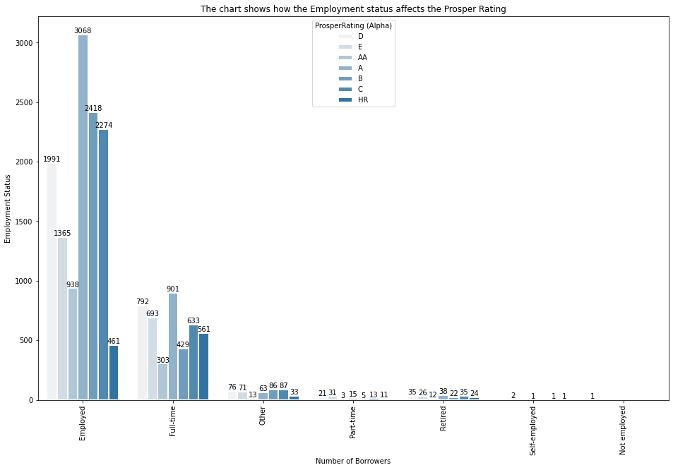

```python
print('**CHART B1**')
plt.figure(figsize = [16,10])
plt.xticks(rotation = 90);
ax = sns.countplot(data = data_copy, x = 'EmploymentStatus', hue = 'ProsperRating (Alpha)',color = base_color,edgecolor='white', linewidth=2);
plt.title('The chart shows how the Employment status affects the Prosper Rating');
ax.bar_label(ax.containers[0]);
ax.bar_label(ax.containers[1]);
ax.bar_label(ax.containers[2]);
ax.bar_label(ax.containers[3]);
ax.bar_label(ax.containers[4]);
ax.bar_label(ax.containers[5]);
ax.bar_label(ax.containers[6]);
plt.ylabel('Employment Status');
plt.xlabel('Number of Borrowers');
```

```
** CHART U2 **
```

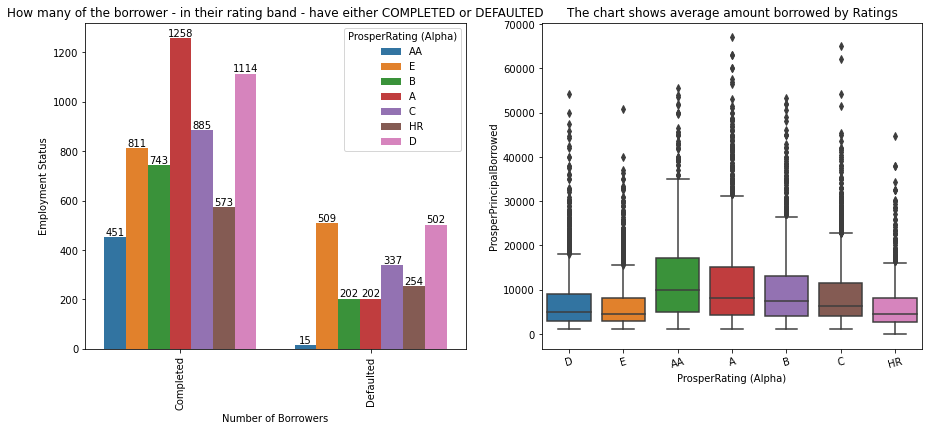

```python
print('** CHART U2 **')

plt.figure(figsize = [15, 6])

plt.subplot(1,2,1);
plt.xticks(rotation = 90);
ax = sns.countplot(data = temp, x = 'TransformedCategory', hue = 'ProsperRating (Alpha)');
plt.title('How many of the borrower - in their rating band - have either COMPLETED or DEFAULTED');
ax.bar_label(ax.containers[0]);
ax.bar_label(ax.containers[1]);
ax.bar_label(ax.containers[2]);
ax.bar_label(ax.containers[3]);
ax.bar_label(ax.containers[4]);
ax.bar_label(ax.containers[5]);
ax.bar_label(ax.containers[6]);
plt.ylabel('Employment Status');
plt.xlabel('Number of Borrowers');

plt.subplot(1,2,2);
plt.title('The chart shows average amount borrowed by Ratings')
ax1 = sns.boxplot(data=data_copy, x='ProsperRating (Alpha)', y='ProsperPrincipalBorrowed')
plt.xticks(rotation=15);
plt.ylim(ax1.get_ylim());
```

```
** CHART U3 **
```

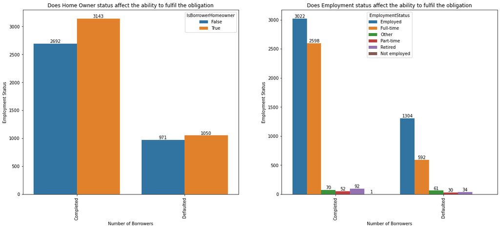

```python
print('** CHART U3 **')
plt.figure(figsize = [20,8])

plt.subplot(1, 2, 1);
plt.xticks(rotation = 90);
ax = sns.countplot(data = temp, x = 'TransformedCategory', hue = 'IsBorrowerHomeowner');
plt.title('Does Home Owner status affect the ability to fulfil the obligation');
ax.bar_label(ax.containers[0]);
ax.bar_label(ax.containers[1]);
plt.ylabel('Employment Status');
plt.xlabel('Number of Borrowers');

plt.subplot(1, 2, 2);
plt.xticks(rotation = 90);
ax = sns.countplot(data = temp, x = 'TransformedCategory', hue = 'EmploymentStatus');
plt.title('Does Employment status affect the ability to fulfil the obligation');
ax.bar_label(ax.containers[0]);
ax.bar_label(ax.containers[1]);
ax.bar_label(ax.containers[2]);
ax.bar_label(ax.containers[3]);
ax.bar_label(ax.containers[4]);
ax.bar_label(ax.containers[5]);
plt.ylabel('Employment Status');
plt.xlabel('Number of Borrowers');
```

#### Is there a relationship between the Borrower's Rate and their StatedMonthly Income?

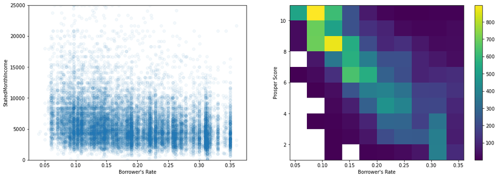

```python
plt.figure(figsize = [18, 6])

plt.subplot(1, 2, 1);
plt.scatter(data = data_copy, x = 'BorrowerRate', y = 'StatedMonthlyIncome',alpha =1/20);
plt.xlabel("Borrower's Rate");
plt.ylabel('StatedMonthIncome');
plt.ylim(0,25000);

plt.subplot(1, 2, 2);
plt.hist2d(data = data_copy, x = 'BorrowerRate', y = 'ProsperScore', cmin=0.8)
plt.colorbar()
plt.xlabel("Borrower's Rate");
plt.ylabel('Prosper Score');
```

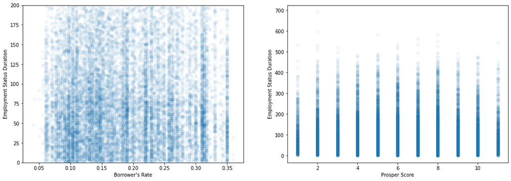

```python
plt.figure(figsize = [18, 6])

plt.subplot(1, 2, 1);
plt.scatter(data = data_copy, x = 'BorrowerRate', y = 'EmploymentStatusDuration',alpha =1/20);
plt.xlabel("Borrower's Rate");
plt.ylabel('Employment Status Duration');
plt.ylim(0,200);

plt.subplot(1, 2, 2);
plt.scatter(data = data_copy, x = 'ProsperScore', y = 'EmploymentStatusDuration',alpha =1/20)
plt.xlabel("Prosper Score");
plt.ylabel('Employment Status Duration');
```

- Chart B1 shows that the employed(including fully employed) borrowers are more, and they also have more borrowers withing the A-C rating.
- More of the borrowers who have completely fulfil their obligations have the rating 'A'
- Borrowers with 'AA' rating seldomly default on their obligations to repay their loans.
- The Prosper ratings of the borrower's affect the loan amount is granted, the 'AA' and 'A' rated borrowers have more average proincipal borrowed compared to the borrowers in other rating band.
- Both Home Owner status and Employment status have an impact on the ability of the borrower to fulful their obligation.
- There is a relationship between the borrower's prosper score and their respective rate.
- Employment status of the borrower does not affect the borrower's rate or prosper score.

### Multivariate Exploration

#### Is the Home Owner status and Prosper Rating a factor that determines the principal amount borrowed?

```python
order_3 = data_copy['ProsperRating (Alpha)'].value_counts(normalize = True).index
```

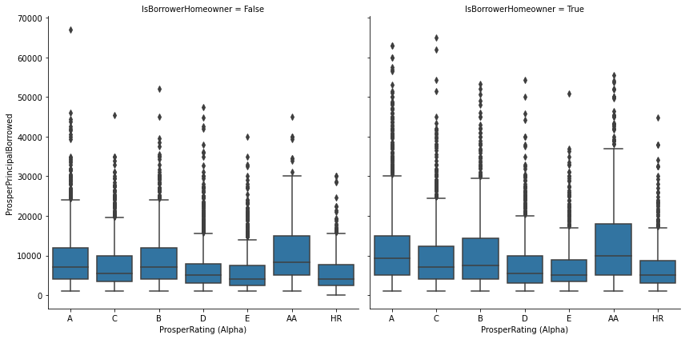

```python
g = sns.FacetGrid(data = data_copy, col = 'IsBorrowerHomeowner', height = 6, margin_titles=True);
g.map(sns.boxplot, 'ProsperRating (Alpha)', 'ProsperPrincipalBorrowed', order = order_3);
```

- The average amount borrowed to home owners with high prosper rating is clearly more than homeowners with prosper rating, same also apply for borrowers who don't own a home.
- The unemployed borrowers have a 'D' rating
- All the High Risk borrowers, irrespective of their Employment status have their at 30% or more.
- All the AA rated borrowers, irrespective of their Employment status have their at 10% or less.

#### Is the Employment Status and Prosper Rating a factor that determines the borrower's rate?

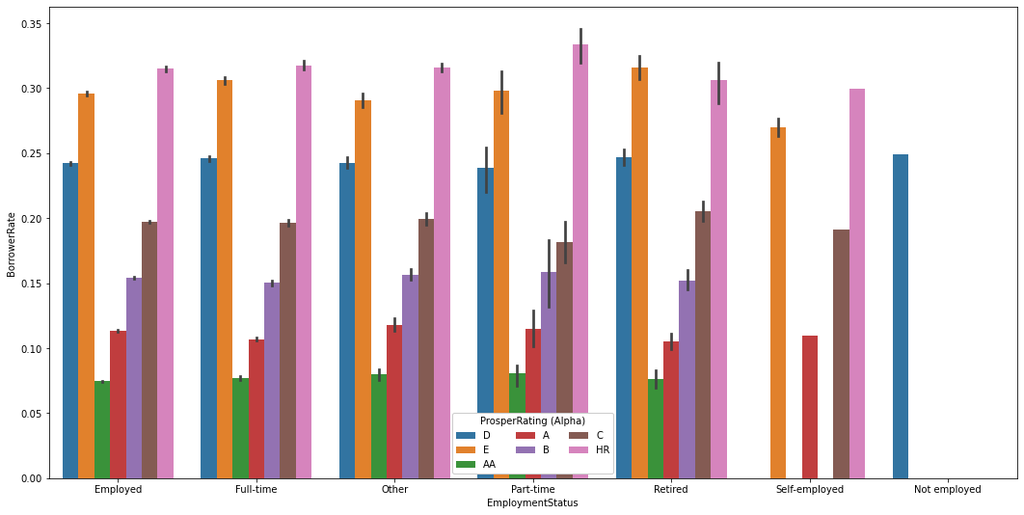

```python
plt.figure(figsize = [18, 9])
ax = sns.barplot(data = data_copy, x = 'EmploymentStatus', y = 'BorrowerRate', hue = 'ProsperRating (Alpha)');
ax.legend(loc = 8, ncol = 3, framealpha = 1, title = 'ProsperRating (Alpha)');
```

#### A correlation(Heat Map) to show the relationship between the numeric features.

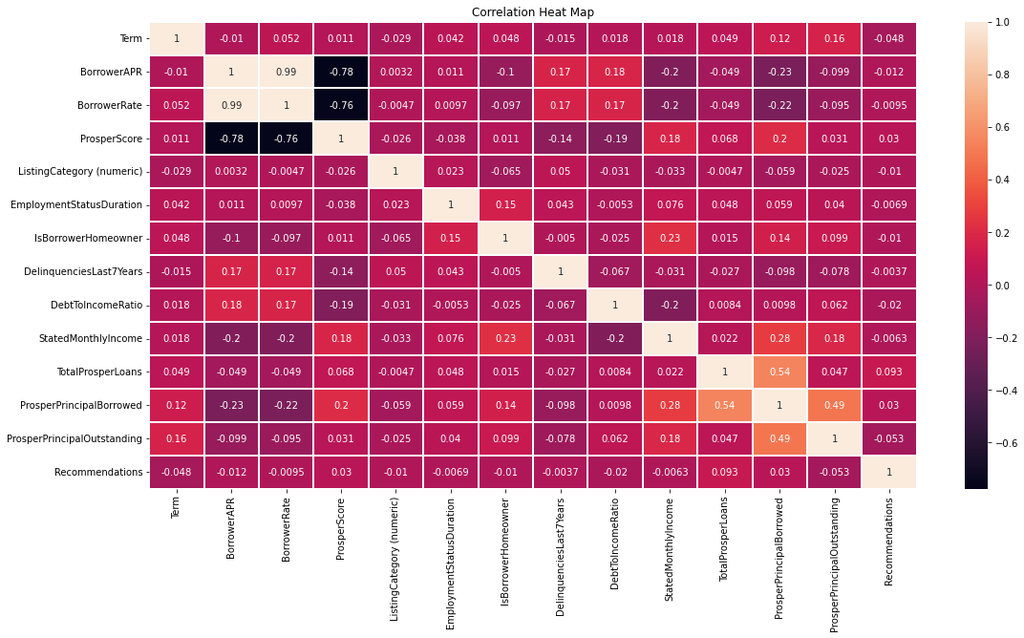

```python
plt.figure(figsize = [18, 9]);
sns.heatmap(data_copy.corr(), linewidth = 2, annot=True);
plt.title('Correlation Heat Map');
```

## Conclusions

- The distribution of the Monthly income of the borrowers as stated by them shows that the median of the data is around USD 5,000 , which means that most of the borrowers earn around USD5k on an average.
- The distribution of the borrower's rating show that the A rated borrowers are more that all the other ratings.
- More of the borrowers who have completely fulfil their obligations have the rating 'A'
- The average amount borrowed to home owners with high prosper rating is clearly more than homeowners with prosper rating, same also apply for borrowers who don't own a home.
- The Prosper ratings of the borrower's affect the loan amount is granted, the 'AA' and 'A' rated borrowers have more average principal borrowed compared to the borrowers in other rating band.
- The unemployed borrowers have a 'D' rating
- Borrowers with 'AA' rating seldomly default on their obligations to repay their loans.
- Both Home Owner status and Employment status have an impact on the ability of the borrower to fulful their obligation.